# Chapter 7 Summary

## Setup

```r
# setwd("/Users/anjali/Documents/university/Econ_5305/code_directory/Chapter7")
rm(list = ls())
```

```r
library(openxlsx)
library(readxl)
library(ggplot2)
library(dynlm)
library(forecast)
```

## Question 2

#### 2.1 Read data on unemployed persons

```r
data_1 <- read_excel("ch7_q2.xlsx")
View(data_1)

# read the time series for unemployment
T_UNEMPLOYED<-ts(data_1$UNEMPLOYED,frequency=12,start=c(1948,1,1), end =c(2023,3,1))
```

#### 2.2 Preliminary EDA

```r
cat("Unemployment Level (seasonally Adjusted)")
```

```
Unemployment Level (seasonally Adjusted)
```

```r
summary(T_UNEMPLOYED)
```

```
    Min.  1st Qu.   Median     Mean  3rd Qu.     Max.
 1596000  4018500  6604000  6599465  8228000 23050000
```

```r
cat("Standard deviation: ", sd(T_UNEMPLOYED))
```

```
Standard deviation:  3077276
```

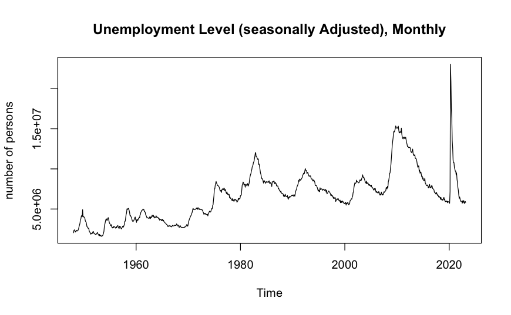

```r
plot.ts(T_UNEMPLOYED, main="Unemployment Level (seasonally Adjusted), Monthly",ylab ="number of persons")
```

**Key Findings:** The graph looks like it has an upward trend along with the presence of cycles. There is some reversion and back and forth that is happening.The upward overall trend of unemployed persons is also expected as it reflects the population growth as well. Summary statistics shows the mean unemployed persons is around 6.6 million. We need to see the ACF and PACF to analyse further.

#### 2.3 Autocorrelation for unemployment level

```r
acf(T_UNEMPLOYED,lag.max= 20, plot = FALSE, main = "ACF for Unemployment Level (seasonally Adjusted)")
```

```
Autocorrelations of series ‘T_UNEMPLOYED’, by lag

0.0000 0.0833 0.1667 0.2500 0.3333 0.4167 0.5000 0.5833 0.6667 0.7500 0.8333 0.9167 1.0000
 1.000  0.980  0.958  0.940  0.922  0.907  0.893  0.880  0.868  0.855  0.841  0.828  0.814
1.0833 1.1667 1.2500 1.3333 1.4167 1.5000 1.5833 1.6667
 0.801  0.788  0.774  0.761  0.748  0.736  0.725  0.714
```

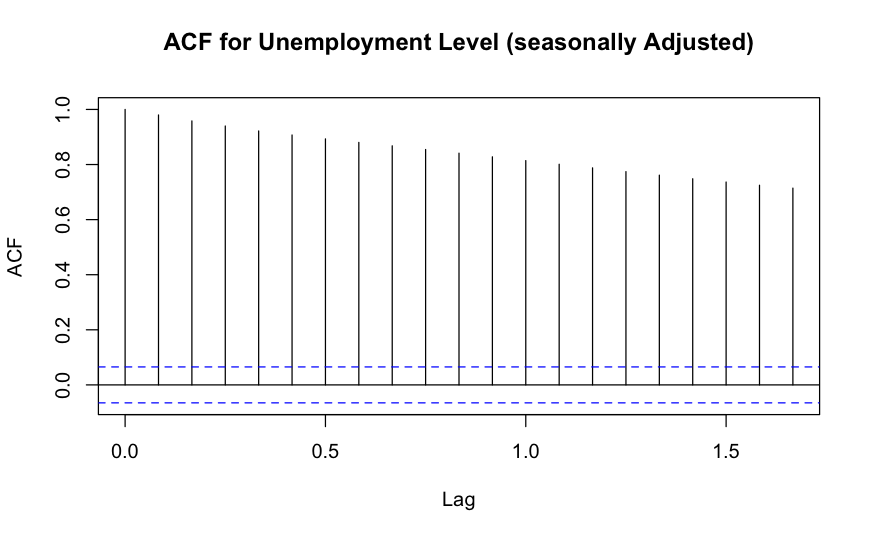

```r
acf(T_UNEMPLOYED,lag.max= 20, plot = TRUE, main = "ACF for Unemployment Level (seasonally Adjusted)")
```

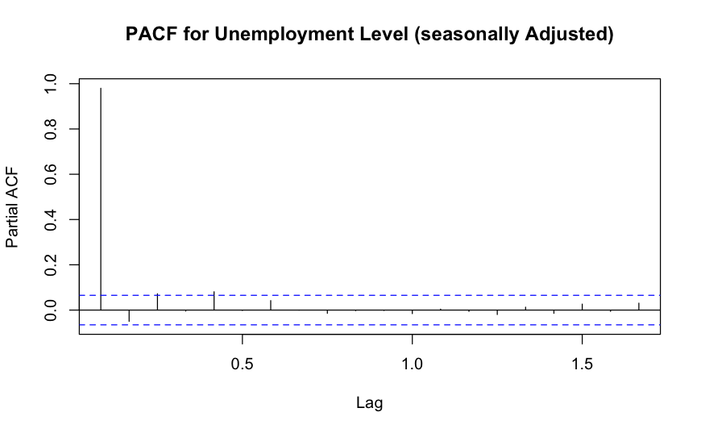

```r
pacf(T_UNEMPLOYED,lag.max= 20, plot = TRUE, main = "PACF for Unemployment Level (seasonally Adjusted)")
```

**Key Findings:** The autocorrelation coefficients for a time series provide information about how observations at different lags are related to each other. The autocorrelation function (ACF) plot visualizes these relationships and reveals important patterns and dynamics of the time series.

With the ACF plot of unemployment data, we can see that there is a positive association between observations at different lags, which means that previous values have a significant influence on future values. However, the degree of association decreases as the lag increases, indicating that the effect of past values gradually fades out over time.

We see that there are infinite spikes with the autocorrelation falling. The first spike is at 0.98 which is less than 1. A necessary and sufficient condition for an AR(1) process to be covariance stationary is that |phi| < 1. This indicates that we may be able to model the process ar a AR(1) process with phi (persistence) = 0.98.

Therefore, I think AR(1) model would be good to explain this data.

#### 2.4 Calculate auto-correlation functions for growth series

```r
# calculate growth rates by taking the difference of the log (natural log)
G_UNEMPLOYED <- 100*diff(log(T_UNEMPLOYED))
```

```r
cat("Change in Unemployment Level (seasonally Adjusted) - Descriptive Statistics:\n")
```

```
Change in Unemployment Level (seasonally Adjusted) - Descriptive Statistics:
```

```r
summary(G_UNEMPLOYED)
```

```
    Min.  1st Qu.   Median     Mean  3rd Qu.     Max.
-20.7201  -2.1180  -0.1034   0.1169   1.8788 116.5809
```

```r
cat("Standard deviation: ", sd(G_UNEMPLOYED))
```

```
Standard deviation:  5.568925
```

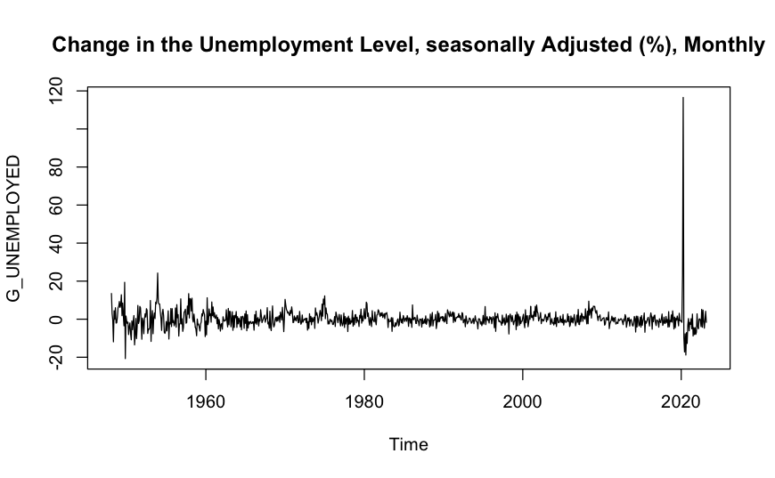

```r
plot.ts(G_UNEMPLOYED, main="Change in the Unemployment Level, seasonally Adjusted (%), Monthly")
```

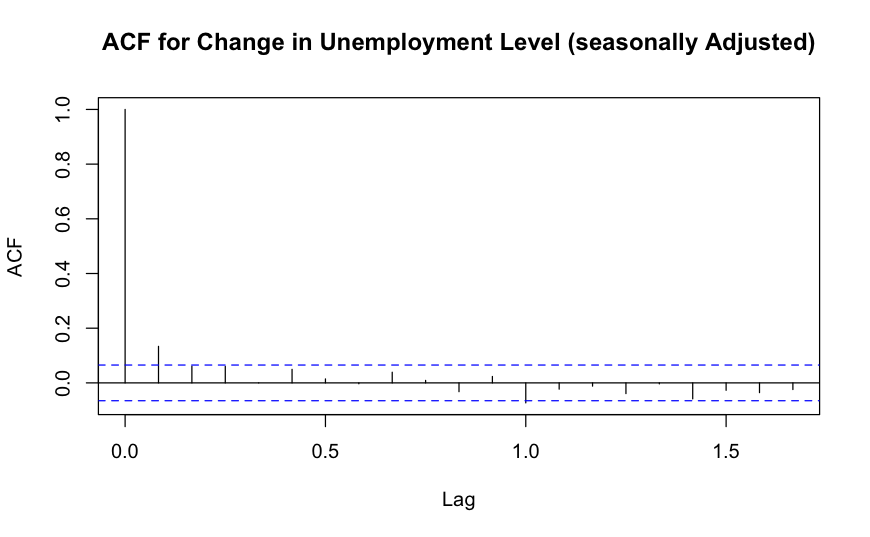

```r
acf(G_UNEMPLOYED,lag.max= 20, plot = TRUE, main = "ACF for Change in Unemployment Level (seasonally Adjusted)")
```

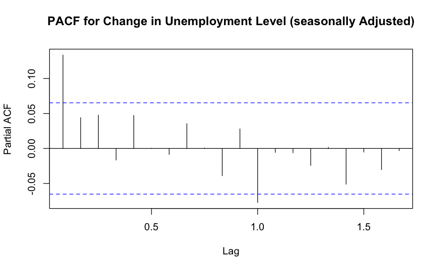

```r
pacf(G_UNEMPLOYED,lag.max= 20, plot = TRUE, main = "PACF for Change in Unemployment Level (seasonally Adjusted)")
```

**Key Findings:** Looking at the ACF we see 1 very small spike for Lag 1. This looks quite close to noise. We could also try to Model the growth series as MA(1) process.

#### Conclusion

```r
# AR(1)
model_1<-arima(x=T_UNEMPLOYED,order=c(1,1,0))
model_1
```

```
Call:
arima(x = T_UNEMPLOYED, order = c(1, 1, 0))

Coefficients:
         ar1
      0.0463
s.e.  0.0332

sigma^2 estimated as 3.559e+11:  log likelihood = -13275.57,  aic = 26555.15
```

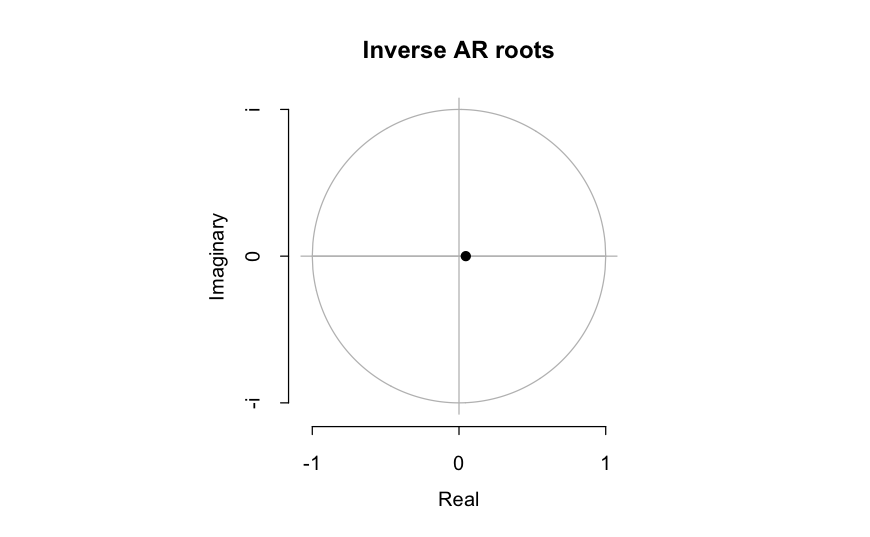

```r
plot(model_1)
```

## Question 3

#### 3.1 Read data on per capita income for California

```r
data_q3 <- read_excel("ch7_q3_q4_final.xls")
View(data_q3)
ts_california <- ts(data_q3$CALIFORNIA, start = c(1929, 1, 1), frequency = 1)
```

#### 3.2 Timeseries plots of per capita income in California, ACF, PACF

```r
summary(ts_california)
plot(ts_california, main = "Personal Income in California", ylab = "Per Capita Income")

acf(ts_california, lag.max = 20, plot = TRUE, na.action = na.pass)
pacf(ts_california, lag.max = 20, plot = TRUE, na.action = na.pass)
```

[output not shown]

**Interpretation:** The ACF shows infinite spikes that are slowly falling which indicates we could model the time series using an AR(1) process. However, it might be interesting to calculate the per-capita income growth as shown in the textbook fig 7.7 to see if we can identify any other patterns in the ACF. This is a highly persistent series and hence we see the upward trend. The times series does not show any reversion to the mean and does not look stationary.

#### 3.3 Analysis for per-capita income growth california -plots of per capita income in California, ACF, PACF

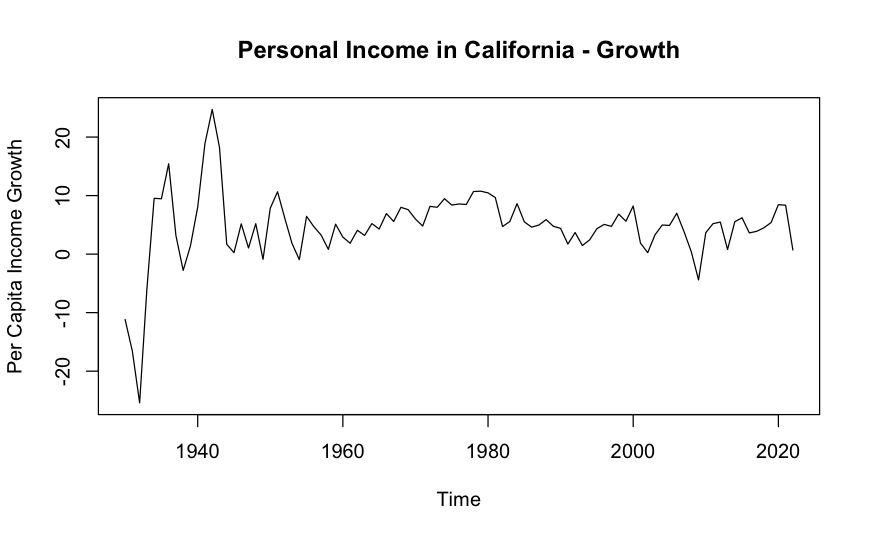

```r
# calculate growth rates by taking the difference of the log (natural log)
gs_california <- 100*diff(log(ts_california))
plot(gs_california, main = "Personal Income in California - Growth", ylab = "Per Capita Income Growth")
```

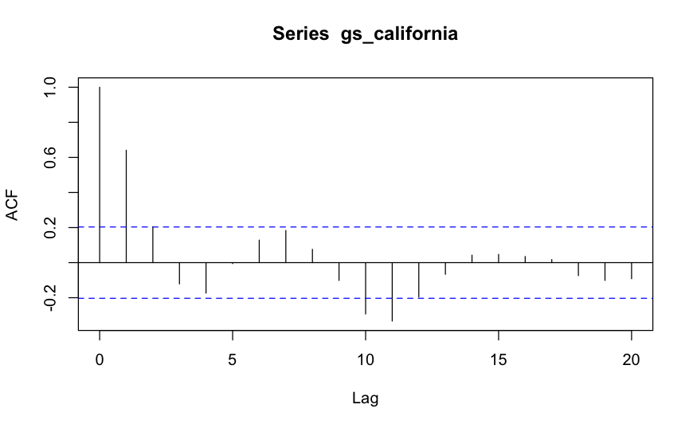

```r
acf(gs_california, lag.max = 20, plot = TRUE, na.action = na.pass)
```

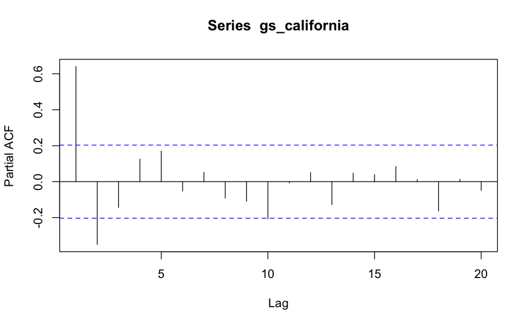

```r
pacf(gs_california, lag.max = 20, plot = TRUE, na.action = na.pass)
```

**Interpretation** Looking at the ACF and PACF of the growth series we see 2 spikes in the ACF after which there is inversion. Looking at the PACF again we see 2 spikes followed some more smaller spikes (near the blue line) on the 4th, 9th positions. The ACF with 2 spikes indicates an AR(2) model.

```r
# model the growth series using AR(2) process
model_california_ar2 <-arima(x=gs_california,order=c(2,0,0))
model_california_ar2
```

```
Call:
arima(x = gs_california, order = c(2, 0, 0))

Coefficients:
         ar1      ar2  intercept
      0.9091  -0.3698     4.5851
s.e.  0.0976   0.1049     0.9598

sigma^2 estimated as 18.17:  log likelihood = -267.25,  aic = 542.5
```

```r
# using auto.arima to see what auto arima suggests - ARIMA(3,0,2) with non-zero mean
model_california_auto <- auto.arima(gs_california)
model_california_auto
```

```
Series: gs_california
ARIMA(3,0,2) with non-zero mean

Coefficients:
         ar1      ar2     ar3      ma1     ma2    mean
      2.1433  -2.0434  0.7879  -1.4145  0.8462  4.0755
s.e.  0.1067   0.1202  0.0768   0.1499  0.0996  1.5652

sigma^2 = 16.62:  log likelihood = -261.19
AIC=536.37   AICc=537.69   BIC=554.1
```

#### 3.4 - 3 step forecast

```r
forecast_california <- forecast(model_california_ar2, h=3)
summary(forecast_california)
```

```
Forecast method: ARIMA(2,0,0) with non-zero mean

Model Information:

Call:
arima(x = gs_california, order = c(2, 0, 0))

Coefficients:
         ar1      ar2  intercept
      0.9091  -0.3698     4.5851
s.e.  0.0976   0.1049     0.9598

sigma^2 estimated as 18.17:  log likelihood = -267.25,  aic = 542.5

Error measures:
                     ME     RMSE      MAE       MPE     MAPE      MASE        ACF1
Training set 0.02537777 4.263122 3.082108 -8.437174 111.7383 0.9219407 -0.04864145

Forecasts:
```

|  | Point Forecast | Lo 80 | Hi 80 | Lo 95 | Hi 95 |
| --- | --- | --- | --- | --- | --- |
| 2023 | -0.3422126 | -5.805623 | 5.121198 | -8.697778 | 8.013353 |
| 2024 | 1.5422562 | -5.841543 | 8.926056 | -9.750291 | 12.834803 |
| 2025 | 3.6406694 | -4.153454 | 11.434793 | -8.279414 | 15.560753 |

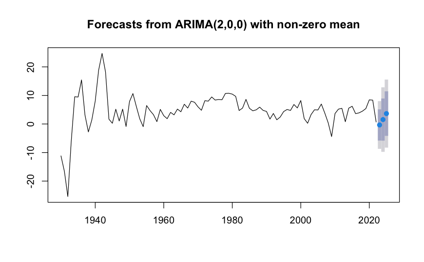

```r
plot(forecast_california)
```

## Question 4

#### 4.1 Loading data

```r
# set periods to where all series have data so no N/A occurs
ts_california<-ts(data_q3$CALIFORNIA, start = c(1929,1,1), frequency = 1)
ts_texas<-ts(data_q3$TEXAS, start = c(1929, 1, 1), frequency = 1)
ts_seattle<-ts(data_q3$SEATTLE, start = c(1929, 1, 1), frequency = 1)
ts_ny <-ts(data_q3$NEWYORK, start = c(1929, 1, 1),frequency = 1)
```

#### 4.2 Quick plot to observe the all the timeseries together

```r
# Line plot
plot(ts_texas, type ='l',col = "blue" , xlab= "observation_date", ylab = "Per capita income ")
lines(ts_seattle, type = 'l', col = "green")
```

```r
lines(ts_california, type = 'l', col = "black")
lines(ts_ny, type = 'l', col = "red")
```

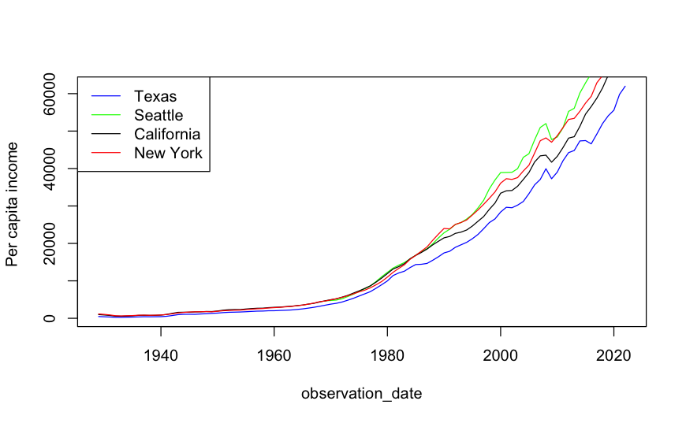

```r
legend("topleft", c("Texas","Seattle","California","New York") ,lty = 1, col = c("blue","green","black","red"))
```

**Note:** The time series plots for all the states have similar trends (not stationary characteristics) so we can do further analysis of ACF and PACF after doing the log-difference transform on all the series to get the growth series.

#### 4.3 Analysis for per-capita income growth for all the states - ACFs and PACFs

```r
california <- 100*diff(log(ts_california))
seattle <- 100*diff(log(ts_seattle))
newyork <- 100*diff(log(ts_ny))
texas <- 100*diff(log(ts_texas))

# combine line plot
plot(texas, type ='l',col = "blue" , xlab= "observation_date", ylab = "Per capita income Growth")
lines(seattle, type = 'l', col = "green")
```

```r
lines(california, type = 'l', col = "black")
lines(newyork, type = 'l', col = "red")
```

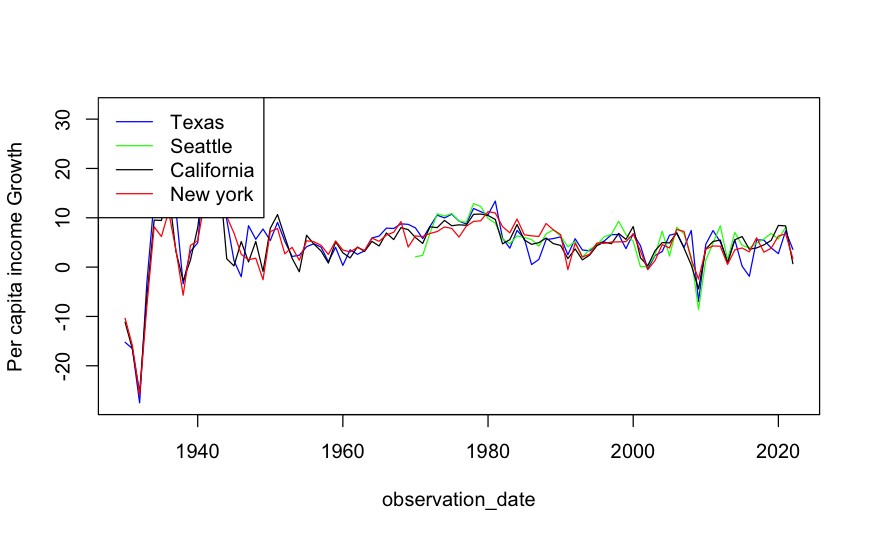

```r
legend("topleft", c("Texas","Seattle","California","New york") ,lty = 1, col = c("blue","green","black","red"))
```

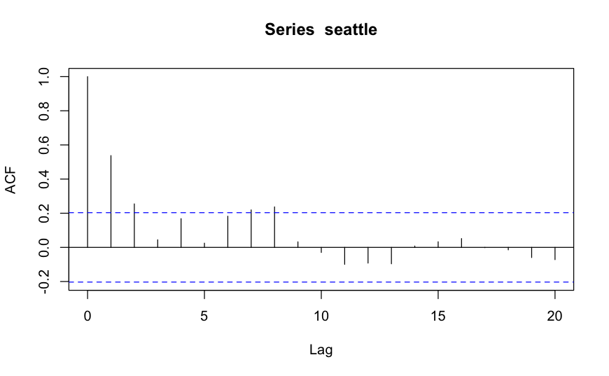

```r
acf(seattle, lag.max = 20, plot = TRUE, na.action = na.pass)
```

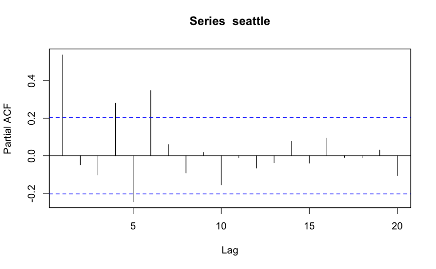

```r
pacf(seattle, lag.max = 20, plot = TRUE, na.action = na.pass)
```

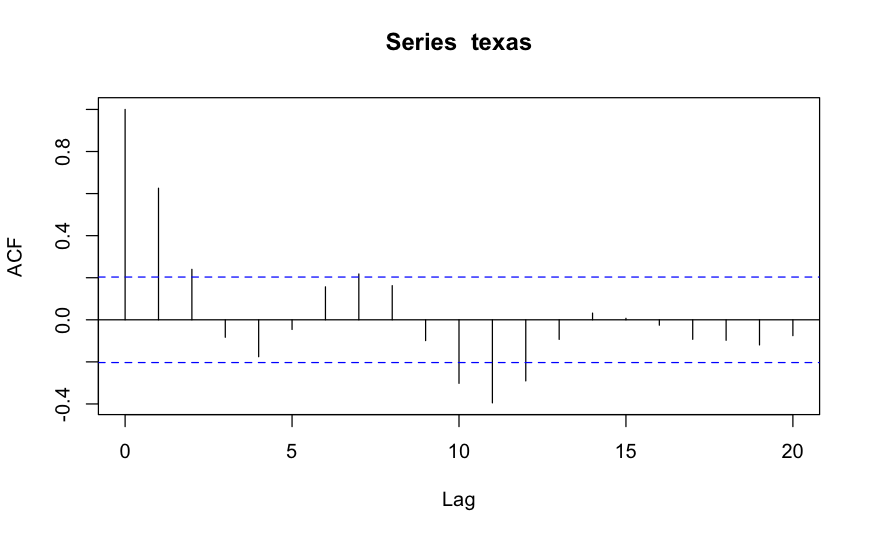

```r
acf(texas, lag.max = 20, plot = TRUE, na.action = na.pass)
```

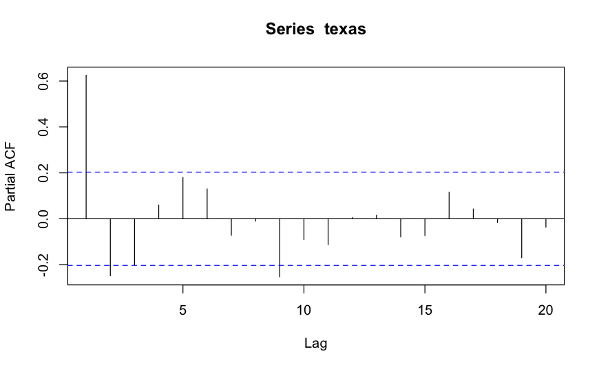

```r
pacf(texas, lag.max = 20, plot = TRUE,na.action = na.pass)
```

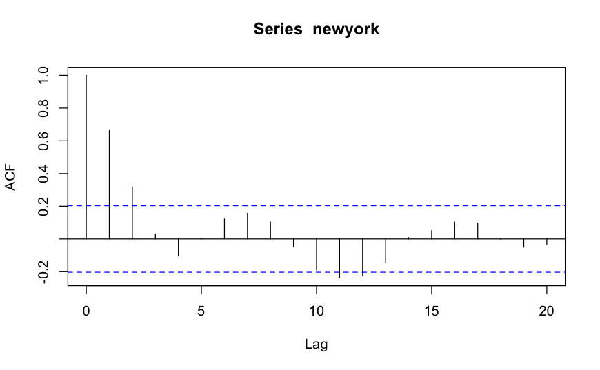

```r
acf(newyork, lag.max = 20, plot = TRUE, na.action = na.pass)
```

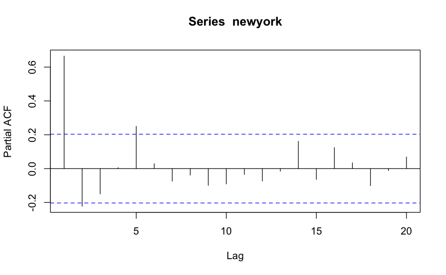

```r
pacf(newyork, lag.max = 20, plot = TRUE, na.action = na.pass)
```

**Key Findings:**

- Seattle - We see in the ACF that there are are 2 spikes AT L1 AND L2 and it reduces. This indicates that a AR process model can been used . Looking at the PACF we see that there are multiple spikes at Lags = 1,4,5 and 6. Based on this analysis I feel that using AR(6) process model maybe a good option. It would be interesting to see if this pattern is arising due to the specific data sample observed. (train test splitting validation will help)
- Texas - We see in the ACF that there are 2 spikes AT L1 AND L2 and the ACF looks like it has a cyclical pattern. This indicates that a AR process model can been used .Looking at the PACF we see that there are multiple spikes at Lags = 1,2, and 9. Based on this analysis I feel that using AR(9) process model maybe a good option. We could also create an AR(2) model and not consider the 9th spike as it is quite small
- New York - We see in the ACF that there are 2 spikes AT L1 AND L2 and the ACF looks like it has a cyclical pattern. This indicates that a AR process model can been used .Looking at the PACF we see that there are multiple spikes at Lags = 1,2, and 5. Based on this analysis I feel that using AR(5) process model maybe a good. We could also look at and AR(2) since the 5th spike is small as another choice.
- Commonalities are that all the series in the ACF show 2 spikes which then reduce. The PACFs have spikes at different lags and all except Seattle (we have fewer data points here) have prominent spikes at L1 and L2 indicating a general model that could be AR(2)

#### 4.4 AR models for each state

##### Seattle

```r
# AR(6) model for seattle
model_seattle_ar6 <-arima(x=seattle,order=c(6,0,0))
model_seattle_ar6
```

```
Call:
arima(x = seattle, order = c(6, 0, 0))

Coefficients:
         ar1      ar2      ar3     ar4      ar5     ar6  intercept
      0.7527  -0.2199  -0.1644  0.4319  -0.4671  0.3430     5.7851
s.e.  0.1286   0.1509   0.1352  0.1389   0.1488  0.1297     1.0309

sigma^2 estimated as 6.621:  log likelihood = -123.79,  aic = 263.58
```

```r
# AR(2) model for seattle
model_seattle_ar2 <-arima(x=seattle,order=c(2,0,0))
model_seattle_ar2
```

```
Call:
arima(x = seattle, order = c(2, 0, 0))

Coefficients:
         ar1      ar2  intercept
      0.5678  -0.0464     5.6601
s.e.  0.1382   0.1384     0.8506

sigma^2 estimated as 8.94:  log likelihood = -130.91,  aic = 269.83
```

```r
# using auto.arima to see what auto arima suggests - ARIMA(0,1,0) which does not make sense at all
#model_seattle_auto <- auto.arima(seattle)
#model_seattle_auto
```

```r
# forecast using AR(6) model
forecast_seattle <- forecast(model_seattle_ar6, h=3)
summary(forecast_seattle)
```

```
Forecast method: ARIMA(6,0,0) with non-zero mean

Model Information:

Call:
arima(x = seattle, order = c(6, 0, 0))

Coefficients:
         ar1      ar2      ar3     ar4      ar5     ar6  intercept
      0.7527  -0.2199  -0.1644  0.4319  -0.4671  0.3430     5.7851
s.e.  0.1286   0.1509   0.1352  0.1389   0.1488  0.1297     1.0309

sigma^2 estimated as 6.621:  log likelihood = -123.79,  aic = 263.58

Error measures:
                       ME     RMSE      MAE       MPE     MAPE      MASE        ACF1
Training set -0.004244647 2.573189 1.992396 -186.7651 221.5759 0.7921735 -0.01462943

Forecasts:
```

|  | Point Forecast | Lo 80 | Hi 80 | Lo 95 | Hi 95 |
| --- | --- | --- | --- | --- | --- |
| 2023 | 6.476246 | 2.348747 | 10.603746 | 0.1637809 | 12.78871 |
| 2024 | 5.070124 | 0.787225 | 9.353023 | -1.4800048 | 11.62025 |
| 2025 | 6.267165 | 1.978225 | 10.556105 | -0.2922032 | 12.82653 |

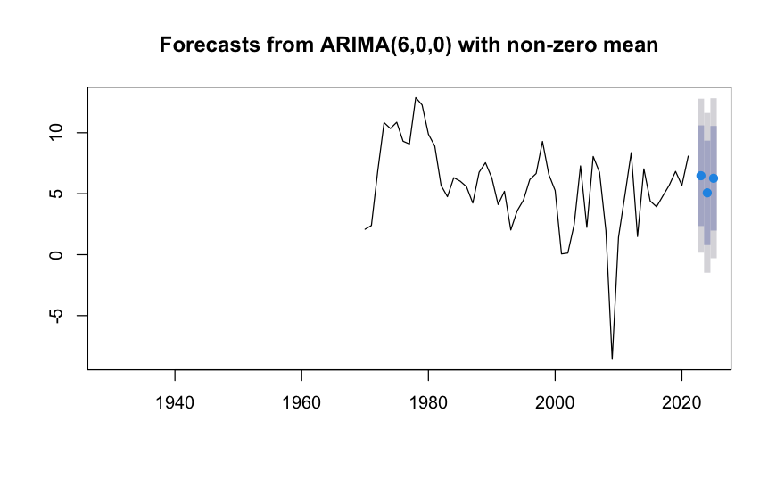

```r
plot(forecast_seattle)
```

#### Texas

```r
# AR(9) model for Texas
model_texas_ar9 <-arima(x=texas,order=c(9,0,0))
model_texas_ar9
```

```
Call:
arima(x = texas, order = c(9, 0, 0))

Coefficients:
         ar1      ar2      ar3      ar4     ar5     ar6      ar7     ar8      ar9
      0.7287  -0.0761  -0.0083  -0.1521  0.0107  0.2754  -0.0925  0.2263  -0.3831
s.e.  0.0992   0.1254   0.1366   0.1336  0.1363  0.1407   0.1435  0.1459   0.1187
      intercept
         5.2606
s.e.     1.0587

sigma^2 estimated as 20.9:  log likelihood = -274.95,  aic = 571.9
```

```r
# AR(2) model for Texas
model_texas_ar2 <-arima(x=texas,order=c(2,0,0))
model_texas_ar2
```

```
Call:
arima(x = texas, order = c(2, 0, 0))

Coefficients:
         ar1      ar2  intercept
      0.8254  -0.2454     5.0388
s.e.  0.1009   0.1065     1.2782

sigma^2 estimated as 27.01:  log likelihood = -285.58,  aic = 579.17
```

```r
# using auto.arima to see what auto arima suggests - ARIMA(3,0,2) with non-zero mean
model_texas_auto <- auto.arima(texas)
model_texas_auto
```

```
Series: texas
ARIMA(3,0,2) with non-zero mean

Coefficients:
         ar1      ar2     ar3      ma1     ma2    mean
      1.6603  -1.5216  0.4564  -0.9757  0.8696  5.2540
s.e.  0.1230   0.1583  0.1266   0.0731  0.1666  1.0961

sigma^2 = 24.64:  log likelihood = -279.21
AIC=572.42   AICc=573.73   BIC=590.15
```

```r
# forecast using AR(9) model
forecast_texas <- forecast(model_texas_ar9, h=3)
summary(forecast_seattle)
```

```
Forecast method: ARIMA(6,0,0) with non-zero mean

Model Information:

Call:
arima(x = seattle, order = c(6, 0, 0))

Coefficients:
         ar1      ar2      ar3     ar4      ar5     ar6  intercept
      0.7527  -0.2199  -0.1644  0.4319  -0.4671  0.3430     5.7851
s.e.  0.1286   0.1509   0.1352  0.1389   0.1488  0.1297     1.0309

sigma^2 estimated as 6.621:  log likelihood = -123.79,  aic = 263.58

Error measures:
                       ME     RMSE      MAE       MPE     MAPE      MASE        ACF1
Training set -0.004244647 2.573189 1.992396 -186.7651 221.5759 0.7921735 -0.01462943

Forecasts:
```

|  | Point Forecast | Lo 80 | Hi 80 | Lo 95 | Hi 95 |
| --- | --- | --- | --- | --- | --- |
| 2023 | 6.476246 | 2.348747 | 10.603746 | 0.1637809 | 12.78871 |
| 2024 | 5.070124 | 0.787225 | 9.353023 | -1.4800048 | 11.62025 |
| 2025 | 6.267165 | 1.978225 | 10.556105 | -0.2922032 | 12.82653 |

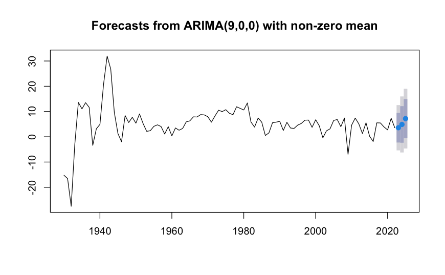

```r
plot(forecast_texas)
```

#### Newyork

```r
# AR(5) model for NY
model_ny_ar5 <-arima(x=newyork,order=c(5,0,0))
model_ny_ar5
```

```
Call:
arima(x = newyork, order = c(5, 0, 0))

Coefficients:
         ar1      ar2      ar3      ar4     ar5  intercept
      0.8282  -0.1261  -0.0490  -0.3443  0.3777     4.2475
s.e.  0.0988   0.1290   0.1468   0.1456  0.1267     1.2711

sigma^2 estimated as 14.09:  log likelihood = -255.78,  aic = 525.56
```

```r
# AR(2) model for NY
model_ny_ar2 <-arima(x=newyork,order=c(2,0,0))
model_ny_ar2
```

```
Call:
arima(x = newyork, order = c(2, 0, 0))

Coefficients:
         ar1      ar2  intercept
      0.8374  -0.1988     4.3069
s.e.  0.1017   0.1102     1.1341

sigma^2 estimated as 15.81:  log likelihood = -260.72,  aic = 529.43
```

```r
# using auto.arima to see what auto arima suggests - ARIMA(2,0,3) with non-zero mean
model_ny_auto <- auto.arima(newyork)
model_ny_auto
```

```
Series: newyork
ARIMA(2,0,3) with non-zero mean

Coefficients:
         ar1      ar2     ma1     ma2     ma3    mean
      0.7778  -0.6767  0.0131  0.6180  0.4586  4.4852
s.e.  0.1401   0.1915  0.1583  0.1495  0.1980  0.9019

sigma^2 = 15.12:  log likelihood = -256.21
AIC=526.42   AICc=527.74   BIC=544.15
```

```r
# forecast using AR(5) model
forecast_ny <- forecast(model_ny_ar5, h=3)
summary(forecast_ny)
```

```
Forecast method: ARIMA(5,0,0) with non-zero mean

Model Information:

Call:
arima(x = newyork, order = c(5, 0, 0))

Coefficients:
         ar1      ar2      ar3      ar4     ar5  intercept
      0.8282  -0.1261  -0.0490  -0.3443  0.3777     4.2475
s.e.  0.0988   0.1290   0.1468   0.1456  0.1267     1.2711

sigma^2 estimated as 14.09:  log likelihood = -255.78,  aic = 525.56

Error measures:
                     ME     RMSE      MAE      MPE     MAPE     MASE        ACF1
Training set 0.08426284 3.753831 2.745592 16.68989 82.53869 0.952539 -0.04668759

Forecasts:
```

|  | Point Forecast | Lo 80 | Hi 80 | Lo 95 | Hi 95 |
| --- | --- | --- | --- | --- | --- |
| 2023 | 1.434664 | -3.376064 | 6.245393 | -5.922710 | 8.792039 |
| 2024 | 1.242090 | -5.004397 | 7.488578 | -8.311088 | 10.795269 |
| 2025 | 2.148321 | -4.654095 | 8.950738 | -8.255077 | 12.551719 |

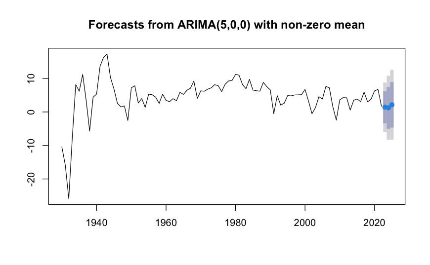

```r
plot(forecast_ny)
```